# Safety Plan

Al Irvine

Al Irvine  
New Graph Environment  
al@newgraphenvironment  
250-777-1518  
Date: 2021-09-28

# Safety Plan - 2021-041-nupqu-elk-fish-passage

The latest version of this pdf can be downloaded [here](https://github.com/NewGraphEnvironment/safety_plan_2021-041-nupqu-elk-fish-passage/raw/main/docs/safety_plan_nupqu-elk-fish-passage.pdf).

A zip file which includes kml (google earth) and gpx (garmin) files of the sites to be potentially assessed can be downloaded [here](https://github.com/NewGraphEnvironment/safety_plan_2021-041-nupqu-elk-fish-passage/raw/main/mapping/sites_nupqu-elk-fish-passage_20210928_kml_gpx.zip). Georeferenced pdf maps can be accessed and downloaded [here](https://hillcrestgeo.ca/outgoing/fishpassage/projects/elk/).

**Accomodations**

Al - Unit 415 - 1500 McDonald Avenue Fernie, BC - Contact - Mark 399hflfib4khcd4ild7h41rgv6si@reply.airbnb.com  
Kyle - Unit 210 - 1500 McDonald Avenue Fernie, BC. - Contact Nick 399hflfibatpklcqtlfpc1yyc8zu@reply.airbnb.com

| project_number | project_name |
| --- | --- |
| 2021-041 | nupqu-elk-fish-passage |

Table 1: Crew members details and emergency contacts

| name | email | phone | satellite | emerg_name | emerg_email | emerg_phone |
| --- | --- | --- | --- | --- | --- | --- |
| Al Irvine | al@newgraphenvironment.com | 250-777-1518 | allanirvine75@inreach.garmin.com | Tara Stark | tara.stark@gmail.com | 250-505-9854 |
| Kyle Prince | kyle@livinglakescanada.ca | 403-308-9702 | Prince11@inreach.garmin.com | Jocelyn Bouchard | jjbouchard9@gmail.com | 403-813-6590 |

# Equipment Checklists

Personal Equipment Checklist

GPS

Ski poles

Suncreen

water

Bugspray

food

Polarized glasses

gloves work

Bear Spray

glasses safety

phone/camera

headlamp

battery pack booster for phone

clinometer

Hat

field vest

first aid kit personal

note book

Waders

Extra clothes

Boots

rain gear

Crew Equipment Checklist

Hand saw

Measuring board

Linesman Gloves x 3

Scale

Backroads Mapbook

Permits

Locational maps

Fish ID book

Background Documents

Site Cards / Field Guide

radio road

Minnow Traps

Inreach

Catfood

Field Safety Plan

Flagging

first aid kit level 1

Laptop w/basecamp

First Aid binder stocked

GPS cable

Throw bags

Lazer level

polaski

Assessment cards fish passage

shovel

UAV

fire extinguisher backpack

Flow meter

fire extinguisher pressurized

ATV

Battery booster

bucket rigid x 2

Compressor 12V

bucket foldable

Rubber boots (no-slip soles)

clove oil kit w/ instructions

Oakton Multimeter

gloves leather

Backpack Electrofisher

sharpies

stop nets x 4

hand lens

salt blocks

ATV gas

loose salt

ATV lock

dip nets x 2

UAV battery charger

tape measure hand

wader disinfectant kit

tape measure eslon

GPS batteries

pilon x 2

ATV helmets

### Nearest Hospitals

[figure not shown]

Elk Valley Hospital - 1501 5 Ave, Fernie, BC V0B 1M0 - 250-423-4453

[figure not shown]

Elkford Health Centre - Interior Health Authority - 212 Alpine Way, Elkford, BC V0B 1H0 - 250-865-2247

## Field Plan

Field work methods will result in products feeding reporting formats such as the [2020 deliverables](https://newgraphenvironment.github.io/fish_passage_elk_2020_reporting_cwf/) and will generally follow procedures in:

- [fish passage assessments](https://www2.gov.bc.ca/assets/gov/environment/natural-resource-stewardship/land-based-investment/forests-for-tomorrow/field-assessment-for-determining-fish-passage-status-of-cbs.pdf) (MoE 2011)
- [habitat confirmations](https://www2.gov.bc.ca/assets/gov/environment/natural-resource-stewardship/land-based-investment/forests-for-tomorrow/checklist-for-fish-habitat-confirmation-201112.pdf) (Fish Passage Technical Working Group 2011).

Presence/absence of fish, species composition/density and distribution limits can be useful for prioritizing which crossings are a best fit for fish passage restoration and help inform follow up monitoring so electrofishing and minnowtrapping may be conducted. Standard Fish and Fish Habitat Inventory Standard Field Form [site cards](https://www2.gov.bc.ca/gov/content/environment/natural-resource-stewardship/laws-policies-standards-guidance/inventory-standards/aquatic-ecosystems) are used to gather habitat data.

A summary of sites to be potentially assessed is included as Table 2 and an overview map of displaying potential sample locations is included as Figure 1.

### Check In Procedures

Call, text or inreach Tara Stark (2505059854) each morning to share the plan for the day (i.e. name of roads and sites). Check in time is before 7 pm each evening although we regularly check in throughout the day (ex. at arrival to site, 1pm and 4pm) on the inreach or by text and report position/provide updates.

#### Procedures for Failed Check-In - for Check in person

Procedures are summarized in the following Figure. If phone call or inReach check-in is not received by 7pm send text to inreach units, call or text cell phones of field crew members. If no response please call accommodations then personal emergency contacts to see if they have heard anything. Wait 1 hour and text inreach, text or call cell phones and personal emergency contacts and accomodations again. Repeat after 2 hours (9 pm) - if no response then notify the RCMP of a missing persons in field.

[figure not shown]

[figure not shown]

Figure 1. Map of potential sampling areas. High priority sites in red and moderate priority in green.

Table 2: CWF - Potential sample locations.

| id_xing | Stream | east | north | source | id_map | comments | sp_upstr |
| --- | --- | --- | --- | --- | --- | --- | --- |
| 61504 | Coal Creek | 645312.9 | 5483687 | cwf | 082G.113 | Bridge | {BT,CT,CT/RB,WCT} |
| 197527 | Crossing Creek | 648724.3 | 5548196 | cwf | 082J.103 | Dry last year. Lots of survey sites and no fish. Not likely of any value! | {EB} |
| 1004600533 | Chauncey Creek | 656890.0 | 5554160 | cwf | 082J.103 | Ford | {WCT} |
| 1004600762 | Fording River | 651282.0 | 5562574 | cwf | 082J.103 | Recently replaced multiplate? | {WCT} |
| 1004601280 | Harmer Trib | 659427.0 | 5517583 | cwf | 082G.119 | Ford (likely) | {WCT} |
| 1004601704 | Morrissey Creek | 650166.0 | 5473852 | cwf | 082G.108 | Ford | – |
| 1004601984 | Lodgepole trib | 654301.7 | 5458678 | cwf | 082G.108 | Could be a decent candidate if not dry | – |
| 1004601993 | Rabbit Creek | 656655.0 | 5431721 | cwf | 082G.103 | Ford (likely) | – |
| 1004601995 | Rabbit Creek | 655890.2 | 5431860 | cwf | 082G.103 | Ford (likely) | – |
| 1004602163 | Morrissey Creek | 651609.1 | 5475661 | cwf | 082G.113 | Above a huge falls | – |
| 1004602359 | Rabbit Creek | 655618.0 | 5431721 | cwf | 082G.103 | Ford (likely) | – |
| 1004602514 | Harmer Creek | 659393.0 | 5517830 | cwf | 082G.119 | Doubt there is a crossing. Dams ~500m upstream | {WCT} |
| 1004602646 | Wigwam trib | 647364.0 | 5452095 | cwf | 082G.108 | Looks like a tiny stream and suspect road is removed since the bridge across the Wigwam is not there | – |
| 1004602949 | Weigert Creek | 647247.0 | 5534524 | cwf | 082G.123 | Deactivated (could confirm with FLNR) | – |
| 1004603334 | Fording River | 651460.9 | 5566706 | cwf | 082J.108 | Ford - in the middle of the mines | {WCT} |
| 1004603413 | Henretta Creek | 654825.0 | 5567436 | cwf | 082J.108 | Ford - walk in | {WCT} |
| 1004603432 | Cadoma trib | 639196.0 | 5591178 | cwf | 082J.113 | Ford (likely). Elk Lakes Park. Waaay in there. | – |
| 1004603480 | Bean Creek | 650539.0 | 5464640 | cwf | 082G.108 | Bridge | – |
| 1004603553 | Bighorn Creek | 663230.0 | 5447429 | cwf | 082G.104 | Ford. | {DV} |
| 1004603791 | Lodgepole Trib | 660586.0 | 5461227 | cwf | 082G.109 | Ford (likely). Road appears overgrown. | {WCT} |
| 1004603793 | Lodgepole Creek | 663619.0 | 5462235 | cwf | 082G.109 | Ford (likely). Road appears overgrown. | {WCT} |
| 1004604677 | Henretta Creek | 652123.3 | 5566424 | cwf | 082J.108 | Fording mine. Massive looking structure. | {WCT} |
| 1004604696 | Henretta Creek | 652346.1 | 5566461 | cwf | 082J.108 | Ford. Stream is not mapped correctly. Not there. | {WCT} |
| 1004605216 | Wigwam trib | 647730.0 | 5449516 | cwf | 082G.103 | Keen to check this out. | – |
| 1004605338 | Wigwam trib | 658388.0 | 5436172 | cwf | 082G.103 | Max 360m to steep gradients | – |
| 1004605499 | Bean trib | 650057.1 | 5463543 | cwf | 082G.108 | Keen | – |
| 1004605937 | Wigwam trib | 662247.0 | 5431294 | cwf | 082G.104 | Keen | – |
| 1004606007 | Weigert Creek | 647156.3 | 5534676 | cwf | 082G.123 | Removed (could confirm with FLNR) | – |
| 1004606129 | Wigwam trib | 649481.2 | 5446732 | cwf | 082G.103 | Keen. Drains snowshoe Lake | {BT,CT,RB,WCT} |
| 1004606284 | Fording River | 652990.0 | 5571951 | cwf | 082J.108 | Ford (likely). Need permission? | – |
| 1004606347 | Bean Creek | 650414.6 | 5463819 | cwf | 082G.108 | Keen | – |
| 1004606370 | Lodgepole Creek | 664905.1 | 5462562 | cwf | 082G.109 | Keen | {WCT} |
| 1004606398 | Lodgepole Creek | 665796.1 | 5462152 | cwf | 082G.109 | Keen | – |
| 1004606411 | Lodgepole Trib | 658765.0 | 5459547 | cwf | 082G.108 | Ford (likely). | {WCT} |
| 1004606545 | Cummings Creek | 644862.0 | 5520738 | cwf | 082G.123 | Keen. Need quad? | – |
| 1004606926 | Bighorn Creek | 664112.2 | 5445241 | cwf | 082G.104 | Keen | – |
| 1004607022 | McCool Creek | 648168.1 | 5499879 | cwf | 082G.118 | Ford (likely) | {WCT} |
| 1004607449 | Ewin Trib | 659283.9 | 5547544 | cwf | 082J.104 | Ford (likely) | – |
| 1024706614 | Henretta Creek | 653180.2 | 5566732 | cwf | 082J.108 | Ford | {WCT} |
| 1024733953 | Lodgepole Trib | 652220.8 | 5461435 | cwf | 082G.108 | Bridge | – |
| 1024734790 | Brûlé Creek | 649910.2 | 5528007 | cwf | 082G.123 | Ford (likely) | {RB,WCT} |
| 1024735049 | Weigert Creek | 650009.9 | 5531958 | cwf | 082G.123 | Ford (assessed last year) | – |
| 1024735443 | Abruzzi Creek | 638867.1 | 5591423 | cwf | 082J.113 | Ford (likely). Elk Lakes Park. Waaay in there. | {WCT} |
| 1100001086 | Harmer Creek | 657050.7 | 5522119 | cwf | 082G.123 | Harmer Creek Dam. Elkview operations. | {WCT} |
| 1100002606 | Boivin Creek | 647275.1 | 5541987 | cwf | 082J.103 | Dam. Elkford water intake? | – |

Table 3: 2020_field_planning - Potential sample locations.

| id_xing | Stream | east | north | source | id_map | comments | sp_upstr |
| --- | --- | --- | --- | --- | --- | --- | --- |
| 50060 | Harvey Creek | 666579.3 | 5461445 | 2020_planning | 082G.109 | Harvey Lake is 1ha lake upstream ~230m upstream of the crossing. | – |
| 50061 | Fuel Creek | 667651.2 | 5459223 | 2020_planning | 082G.109 | Large stream but dry during assessment. WCT known upstream and wetted at 50151 (ford) located 600m upstream. | {WCT} |
| 50063 | Kisoo Creek | 668960.5 | 5458806 | 2020_planning | 082G.109 | Relatively large channel width. Good flow and hab value rated high. | – |
| 50072 | – | 682784.9 | 5447731 | 2020_planning | 082G.104 | Small stream with good flow in photos. Assessment comments indicate good gravels. Very close to the mainstem of the Flathead. | – |
| 50073 | – | 682180.0 | 5446356 | 2020_planning | 082G.104 | Fairly steep. comments indicate “WCT found upstream by Artech in 1995 according to Habitat Wizard” | – |
| 50075 | – | 683797.4 | 5445297 | 2020_planning | 082G.104 | Smaller stream. | – |
| 50081 | – | 681879.8 | 5443723 | 2020_planning | 082G.104 | Large stream. Potential barrier. | – |
| 50084 | – | 680147.4 | 5439436 | 2020_planning | 082G.104 | Fish observed at outlet. Falls in FISS just downstream. Culvert appears passable to all life stages/species at time of survey but may be velocity barrier at higher flows. | – |
| 50085 | – | 680488.4 | 5435930 | 2020_planning | 082G.104 | Larger channel width habitat rated as high value. | – |
| 50086 | – | 680428.7 | 5435744 | 2020_planning | 082G.104 | Appears passable at most flows. Rocky mountain sculpin nearby and their swim speeds could be a consideration. | – |
| 50090 | – | 681743.0 | 5430951 | 2020_planning | 082G.104 | If this is the mainstem, habitat upstream at bridge appears mod to high value. | – |
| 50091 | – | 681610.6 | 5431531 | 2020_planning | 082G.104 | Good flow in photos. Smaller channel width. Not on mapped stream location | – |
| 50100 | – | 669510.1 | 5442206 | 2020_planning | 082G.104 | Larger stream but fairly steep with relatively low habitat gain potential. | – |
| 50101 | – | 669469.8 | 5442312 | 2020_planning | 082G.104 | Larger stream with good flow. Gradients model as >15 downstream so naturally occuring barriers are fairly likely. | – |
| 50102 | – | 668217.8 | 5442479 | 2020_planning | 082G.104 | Good flow but very steep then extremely steep upstream. | – |
| 50152 | – | 638002.9 | 5483401 | 2020_field | 082G.113 | – | – |
| 50181 | – | 648276.6 | 5468171 | 2020_field | 082G.108 | – | – |
| 50185 | – | 645679.3 | 5469020 | 2020_field | 082G.108 | – | – |
| 50240 | – | 659199.0 | 5499658 | 2020_planning | 082G.119 | Comments indicate partially embedded and backwatered. Other comments indicate good candidate for bridge. | – |
| 50261 | – | 669029.6 | 5481120 | 2020_field | 082G.114 | – | – |
| 50273 | Robert Creek | 657671.1 | 5506277 | 2020_planning | 082G.118 | Dry channel. Small stream. | – |
| 62120 | – | 676693.1 | 5464482 | 2020_planning | 082G.109 | Small potential habitat gain but assessment comments indicate good rearing habitat and good potential fix candidate. | – |
| 62265 | – | 647692.6 | 5578674 | 2020_planning | 082J.108 | Splits upstream and gets very steep. Grainger indicates “Good potential for fix. Rearing habitat upstream.” | – |
| 62423 | Grave Creek | 660493.7 | 5524263 | 2020_field | 082G.124 | – | {RB,WCT} |
| 62425 | Grave Creek | 661478.0 | 5524388 | 2020_field | 082G.124 | – | {WCT} |
| 62426 | Grave Creek | 661662.7 | 5524440 | 2020_field | 082G.124 | – | {WCT} |
| 197533 | Brûlé Creek | 651625.5 | 5528887 | 2020_field | 082G.123 | – | {BT,DV,RB,WCT} |
| 197534 | Weigert Creek | 650147.8 | 5532049 | 2020_field | 082G.123 | – | – |
| 197542 | Hartley Creek | 643536.7 | 5490723 | 2020_field | 082G.113 | – | {DV,EB,WCT} |
| 197555 | – | 646737.2 | 5554528 | 2020_field | 082J.103 | – | – |
| 197559 | Brûlé Creek | 651512.4 | 5528837 | 2020_field | 082G.123 | – | {RB,WCT} |
| 1004600156 | – | 641368.8 | 5487802 | 2020_planning | 082G.113 | Industrial area with stream splitting 3 ways just upstream. | {EB,LSU,SP,WCT} |
| 1004600264 | – | 666528.9 | 5472653 | 2020_planning | 082G.109 | WCT upstream with modelled low gradient habitat. Smaller watershed though. | {WCT} |
| 1004600267 | – | 666187.7 | 5472563 | 2020_planning | 082G.109 | Mottled Sculpin upstream. | {BT,CBA} |
| 1004600621 | Quail Creek | 645057.0 | 5492118 | 2020_planning | 082G.113 | Private agricultural land. Very low gradient so suspect passable at most flows. | – |
| 1004601149 | – | 659817.1 | 5528849 | 2020_planning | 082G.124 | WCT upstream. | {WCT} |
| 1004601582 | – | 641508.0 | 5477910 | 2020_planning | 082G.113 | Stream splits with numerous crossings upstream. | – |
| 1004601687 | – | 670843.0 | 5469802 | 2020_planning | 082G.109 | Large amount of lower grade habitat modelled upstream. Survey site from Kokannee 2001 (http://a100.gov.bc.ca/pub/acat/public/viewReport.do?reportId=29) upstream 600m. | – |
| 1004602098 | – | 657221.1 | 5479085 | 2020_planning | 082G.113 | Crossing appears to be likely located 40m to north-east. Interior Reforestation sample site just upstream. No ecocat report link. | – |
| 1004602218 | – | 654343.0 | 5497892 | 2020_planning | 082G.118 | Large amount of potential habitat but suspect deactivated road. Review before surveying. | {WCT} |
| 1004602564 | – | 667163.0 | 5464077 | 2020_planning | 082G.109 | Steeper habitat upstream. | – |
| 1004602620 | – | 680897.0 | 5453543 | 2020_planning | 082G.109 | Kokanee 2001 (http://a100.gov.bc.ca/pub/acat/public/viewReport.do?reportId=29) report resident fish population does not have access to Flathead river at FISS site downstream. | – |
| 1004602726 | Flanders Brook | 697247.9 | 5446252 | 2020_planning | 082G.105 | Seems like road may be deactivated in aerial imagery. Recommend checking with local foresters. | – |
| 1004602869 | Couldrey Creek | 667844.0 | 5434398 | 2020_planning | 082G.104 | Suspect deactivation from review of aerial imagey. Large potential habitat gain. | – |
| 1004603040 | – | 648387.0 | 5545039 | 2020_planning | 082J.103 | Private land. | {EB,WCT} |
| 1004603477 | Burnham Creek | 675878.1 | 5436608 | 2020_planning | 082G.104 | Large watershed with WCT know upstream. Good candidate. | {WCT} |
| 1004603597 | – | 675469.0 | 5451829 | 2020_planning | 082G.104 | Step-pool system. Relatively larger watershed. BT close by. | – |
| 1004603725 | Pollock Creek | 678149.9 | 5469459 | 2020_planning | 082G.109 | Large stream. | {BT,WCT} |
| 1004603904 | – | 668900.0 | 5468357 | 2020_planning | 082G.109 | Decent amount of habitat upstream in 5-8% slope class. Road may be overgrown and/or deactivated by appearance of google satelite imagery. | – |
| 1004603908 | McLatchie Creek | 667049.0 | 5464485 | 2020_planning | 082G.109 | Steeper habitat upstream. | – |
| 1004604006 | Gardner Creek | 647065.1 | 5584911 | 2020_planning | 082J.108 | Primarily wetland type habitat upstream. | {BSU,BT,DV,LSU,MW,WCT} |
| 1004605451 | Nettie Creek | 686581.3 | 5436976 | 2020_planning | 082G.104 | Phase 1 required. WCT known upstream. Connected to Proctor Lake which has recorded RB. Large potential habitat gain. | {CC,WCT} |
| 1004605458 | – | 686473.0 | 5437250 | 2020_planning | 082G.104 | First order watershed. | – |
| 1004606501 | – | 668124.2 | 5468514 | 2020_planning | 082G.109 | Steeper stream. | – |
| 1004606506 | – | 670699.0 | 5469925 | 2020_planning | 082G.109 | Extensive low gradient and wetland habitat upstream. | – |
| 1004606597 | – | 683097.0 | 5444416 | 2020_planning | 082G.104 | Stream splits to mult iple channels just upstream with relatively small - low elevation watershed. | – |
| 1004606751 | Whiting Creek | 652940.4 | 5515013 | 2020_planning | 082G.118 | Railway. Appears potentially backwatered. | – |
| 1004606800 | – | 644278.7 | 5471741 | 2020_planning | 082G.108 | Large railway crossing structures in aerial photo. Suspect passable. | – |
| 1004606821 | Erickson Creek | 659887.7 | 5505156 | 2020_planning | 082G.119 | Immediately adjacent to mine | {BT,DV,EB,WCT} |
| 1004607003 | – | 659238.0 | 5489723 | 2020_planning | 082G.114 | Appears to be PSCIS 50225. | – |
| 1004607273 | Packhorse Creek | 677870.1 | 5463568 | 2020_planning | 082G.109 | Road looks overgrown in aerial imagery. Suspect ford. | {WCT} |
| 1004607406 | – | 659304.0 | 5478557 | 2020_planning | 082G.113 | WCT upsstream. Large habitat gain before next potential barrier. | {WCT} |
| 1004607464 | – | 682774.0 | 5448438 | 2020_planning | 082G.104 | Culvert documented in FISS. Survey sites upstream of crossing. | {WCT} |
| 1004607567 | – | 655995.0 | 5472834 | 2020_planning | 082G.108 | Fish upstream and down. | {TR} |

Also - this is email from Betty  
1. Crossing Creek has been removed from the habitat confirmation list due to low quality habitat.  
2. Brule Creek 1024734790 has been verified to not exist and has been removed from the list.  
3. PSCIS crossings 62181 and 62182 on Dry Creek have been added for reassessment. These have had a habitat confirmation, but at the time the crossing was embedded and considered to be likely passable. This was 9 years ago, so they need to be reassessed.  
4. Hartley Creek dam immediately upstream of PSCIS crossing 197542 has been added to the list. Requires assessment to determine passability by fish; however, a habitat confirmation has already been completed on the road crossing immediately downstream, so no habitat confirmation required.  
5. Dam 2606 remains on the list. This dam is likely not impeding fish passage, as it was supposedly built as a side channel that has since filled in and become disconnected from the main channel. Just need to verify that this is the case.

[figure not shown]

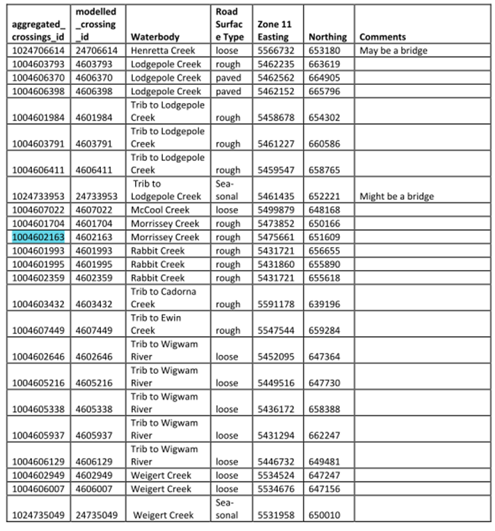

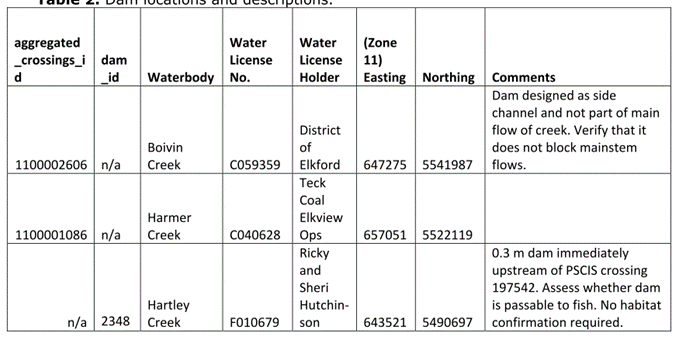

# References

Fish Passage Technical Working Group. 2011. “A Checklist for Fish Habitat Confirmation Prior to the Rehabilitation Fo a Stream Crossing.” https://www2.gov.bc.ca/assets/gov/environment/natural-resource-stewardship/land-based-investment/forests-for-tomorrow/checklist-for-fish-habitat-confirmation-201112.pdf.

MoE. 2011. “Field Assessment for Determining Fish Passage Status of Closed Bottom Structures.” BC Ministry of Environment (MoE). https://www2.gov.bc.ca/assets/gov/environment/natural-resource-stewardship/land-based-investment/forests-for-tomorrow/field-assessment-for-determining-fish-passage-status-of-cbs.pdf.